# AMMS COI Practical

Jason Hendry, Nick Brazeau

August 05, 2022

## Acknowledgements

Sincere thanks to Sophie Berube, Isobel Routledge, Rohan Arambepola, and Amy Wesolowski for contributions and prior practical materials.

## Dependencies for Practical

Please copy and paste the below code chunk in its entirety to your console to download R package libraries needed for this practical. If you are having trouble installing any of the R packages, please ask an instructor for a pre-loaded flash drive.

```r
deps <- c("tidyverse", "vcfR")
deps <- !sapply(deps, function(x){x %in% installed.packages()[,1]} )
if(any(deps)) {
    install.packages(names(deps)[deps])
}
```

## Installing THEREALMcCOIL

Install THEREALMcCOIL pacakge from the EPPIcenter GitHub (or use the pre-cloned repository: `AMMS/COI/THEREALMcCOIL/categorical_method`):

1. In your terminal, navigate to the practical directory `cd AMMS2022/COI`
2. Your instructors have already cloned the code into the directory using the command `git clone https://github.com/EPPIcenter/THEREALMcCOIL.git`. Confirm that the folder `THEREALMcCOIL` is present in `AMMS2022/COI`.
3. Next, navigate to the categorical method directory: `cd THEREALMcCOIL/categorical_method`
4. Complete the installation: `R CMD SHLIB McCOIL_categorical_code.c llfunction_het.c`

If this fails please ask an instructor for a pre-loaded flash drive.

Please now load all of those libraries into this session using the code chunk below. Please copy and paste it in its entirety.

```r
source("R/utils.R")
library(tidyverse)
library(vcfR)
```

Please set *your* R working director so that you are in the `AMMS/COI` directory. If you are having trouble finding that path, you can use the `file.choose` function to help determine its location. To determine what is your current working directory, you can run the command `getwd()`.

# Introduction

## Useful Definitions

- **Definition:** *A locus is a fixed position on a chromosome where a particular genetic marker is located.*
- **Definition:** *An allele is the identity of a particular genetic locus or sequence that is inherited between parents and offspring.*
- **Definition:** *Single-nucleotide polymorphism (SNP). Forms of genetic variation that involve only changes to only a single nucleotide in the geneome are called *single-nucleotide polymorphisms*. *Polymorphism* is latin for ‘multiple forms’; in this case meaning that at this position you may observe different nucleotides in different samples.*
- **Definition:** *An allele is considered to be biallelic if it only has two states in a population (i.e. a biallelic SNP can either be A or T in the population).*
- **Definition:** *Sequencing data consists of sequences of DNA obtained from a DNA sequencing reaction.*
- **Definition:** *Complexity of infection (COI), or equivalently multiplicity of infection, is an integer-valued statistic giving the number of gebnetically distict malaria parasite clones in an individual sample.*
- **Definition:** *A monoclonal malaria infection contains one parasite strain, or “genome” (COI = 1), while a polyclonal infection contains more than one parasite strain (COI > 1).*
- **Definition**: *Heterozygosity ($H$). For a given genetic locus, heterozygosity is a measure of the genetic diversity of samples across a population.*

## Quick review of COI

Complexity of infection (also known as multiplicity of infection) is the number of distinct parasite clones, or parasite strains, that are within an individual sample. If there is only a single clone, the host is said to have a monoclonal infection. If there is more than one clone, the sample is said to be polyclonal.  
Polyclonal infections result through two pathways: (1) superinfection and (2) contransmission. *Superinfection* occurs when an individual is bit by multiple mosquitoes, each carrying distinct clones. *Cotransmission* occurs when a single mosquito is carrying more than one clone and bites, and transmits, multiple clones to the individual concurrently.  
There are serveral motheds for calculating COI. In this practical we will explore two approaches: THEREALMcCOIL, which estimates COI based on the number of heterozygous sites across a set of single-nucleotide polymorphisms (SNPs); and Fws, a statistic for evaluating the genetic complexity within a sample, relative to its population of origin.

## Practical Goals

By the end of this practical, you should be able to do the following: + Load a Variant Call Format (VCF) file into R  
+ Extract and transform it, in preparation for COI estimation  
+ Calculate *p*opulation-*l*evel *a*lternative allele *f*requencie*s* (PLAFs) for a set of SNPs  
+ Run THEREALMcCOIL from R  
+ Compute Fws

Let’s get started!

# 1 A toy example: coin tosses and COI

Before going further, we will introduce a toy example to illustrate how COI and the number of heterozygous sites are related.

Consider a single biallelic SNP in an infection of unknown COI. The process by which that SNP is either heterozygous or homozygous can be conceptualised as series of coin tosses. In particular, each strain in the infection will contribute either the reference or alterative allele; each coin toss in a series contributes either a heads or a tails. A SNP is heterozygous if there is more than one strain present (COI>1), and both the reference and alternative are observed at least once. This is analogous to a series of coin tosses with at least one head and one tail.

Your instructors have implemented a small R function `COIn_toss()` that simulates a series of random coin tosses and relates the outcomes to SNP data. Try running this `COIn_toss()` below:

```r
COIn_toss(COI = 1, loci = 3)
COIn_toss(COI = 2, loci = 3)
COIn_toss(COI = 3, loci = 3)
COIn_toss(COI = 4, loci = 3)
COIn_toss(COI = 5, loci = 3)
COIn_toss(COI = 6, loci = 3)
```

Using this function, answer the following questions:

**Q1:** What is the relationship between COI and the number of heterozygous sites?

Click For Answer

**A1:** *The higher the COI the more heterozygous sites are expected; they are positively correlated.*

**Q2:** Why is it significant that this relationship exists?

Click For Answer

**A2:** *It is significant that COI and the number of heterozygous sites are positively correlated, because it gives us a way to infer COI from genetic data. In particular, if you have a genetic data from a sample of unknown COI, you can look at the number of heterozygous sites to estimate COI. In fact, this is what THEREALMcCOIL does.*

**Q3:** Do samples with a COI>1 always produce heterozygous sites?

Click For Answer

**A3:** *No. By chance you can observe all reference or all alterative alleles at every site (i.e. all heads or tails for each series of coin flips).*

**Q4:** How does having more SNPs influence the probability of observing a heterozygous site?

Click For Answer

**A4:** *For clonal samples it has no effect. For polyclonal infections, it increases the likelihood of observing heterozygous SNPs. This reduces the likelihood that a COI>1 sample will, by chance, contain all homozygous sites.*

**Q5:** How would sequencing error influence the number of heterozygous sites?

Click For Answer

**A5:** *If the sequencing error is random, it will spuriously increase the number of heterozygous sites. This in turn will lead to overestimates of COI.*

Great work! Now let’s get to the real genetic data!

# 2 Loading and exploring a VCF file in R

## 2.1 Background on the data

Let’s start by importing single-nucleotide polymorphism (SNP) data for a set of 113 samples from the Democratic Republic of the Congo (DRC) and 97 samples from Vietnam (VN). These samples were collected and whole-genome sequenced as part of the Pf3k project ([Pf3k](https://www.malariagen.net/)); our goal will be to estimate both COI and Fws for each of them.

SNP data can be derived from a variety of technologies, including molecular barcodes, amplicons, or whole-genome sequencing (WGS) data. In this case, your instructors have extracted information about 96 SNPs from the Pf3k WGS data, ensuring they meet the following criterion: + biallelic  
+ have an intermediate PLAF  
+ spread far apart from each other in the genome  
+ have a sequencing coverage that was within a normal range

**Q6:** Recalling back to the lecture, why could each of the above selection criterion important for COI estimation with THEREALMcCOIL?

Click For Answer

**A6:** *THEREALMcCOIL assumes each SNP is biallelic. An intermediate PLAF is more informative for COI inference, as very low or high PLAF values will only very rarely be heterozygous. THEREALMcCOIL assumes each SNP is unlinked, hence they should be spread far apart along the genome. Removing very high or low coverage sites is a good precaution against read mapping error.*

## 2.2 Importing SNP data into R as a VCF

Regardless of the technology used to generate your SNP data, it will almost always be stored in a Variant Call Format (VCF) file. Briefly, this format stores SNP data as a table, where each row defines an individual SNP. SNPs are defined by mandatory pieces of information, such as the chromosome they reside on and their position, the reference and alternative nucleotides at that position, and so on. For more detail you can visit [VCF format specifications](https://samtools.github.io/hts-specs/VCFv4.3.pdf).

Here, we will use the `vcfR` [package](https://knausb.github.io/vcfR_documentation/) to read in our variant call file (VCF) for the DRC and VN, respectively.

```r
DRCongo <- vcfR::read.vcfR("data/SNPs.DRCongo.setA.random96.vcf")
```

```
## Scanning file to determine attributes.
## File attributes:
##   meta lines: 127
##   header_line: 128
##   variant count: 96
##   column count: 122
##
Meta line 127 read in.
## All meta lines processed.
## gt matrix initialized.
## Character matrix gt created.
##   Character matrix gt rows: 96
##   Character matrix gt cols: 122
##   skip: 0
##   nrows: 96
##   row_num: 0
##
Processed variant: 96
## All variants processed
```

```r
Vietnam <- vcfR::read.vcfR("data/SNPs.Vietnam.setD.random96.vcf")
```

```
## Scanning file to determine attributes.
## File attributes:
##   meta lines: 127
##   header_line: 128
##   variant count: 96
##   column count: 106
##
Meta line 127 read in.
## All meta lines processed.
## gt matrix initialized.
## Character matrix gt created.
##   Character matrix gt rows: 96
##   Character matrix gt cols: 106
##   skip: 0
##   nrows: 96
##   row_num: 0
##
Processed variant: 96
## All variants processed
```

## 2.3 Initial VCF quality control (QC)

As is always good practice, we can check our VCF for missing data and confirm it has the number of SNPs and samples that we expect. Explore the two loaded VCFs to get a sense as to whether the data looks reasonable. One way to do this is through plotting. Use the `extract.gt` function from the vcfR package to pull out the allele depth (first record) for your new VCF. Now plot that allele depth as an initial data exploration using the `heatmap.bp` function from the `vcfR` package.

#### DRC

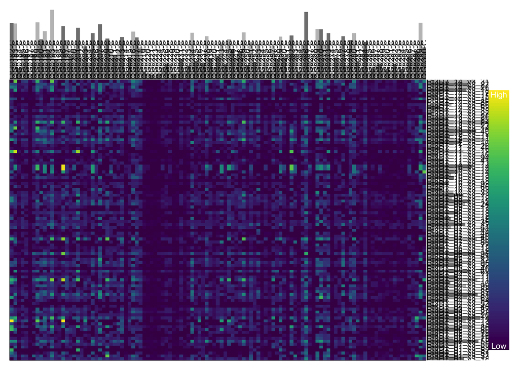

```r
ad_drc <- vcfR::extract.gt(DRCongo, element = "AD", as.numeric = T)
vcfR::heatmap.bp(ad_drc)
```

#### VN

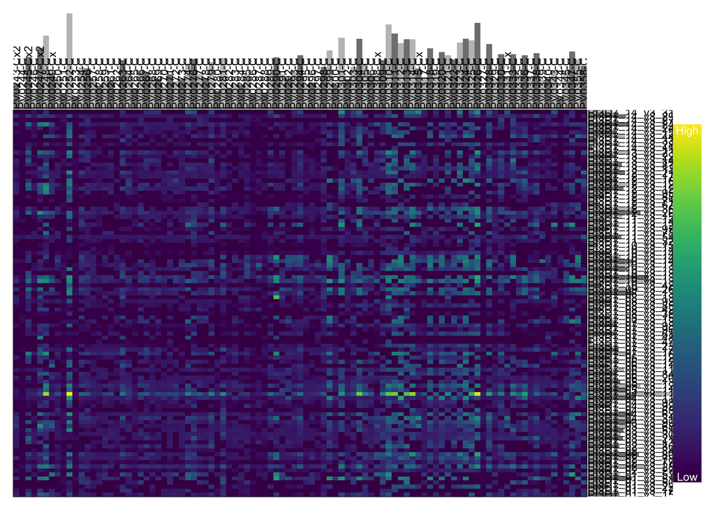

```r
ad_vn <- vcfR::extract.gt(Vietnam, element = "AD", as.numeric = T)
vcfR::heatmap.bp(ad_vn)
```

## 2.4 Preparing the data in tidy format

In this section, we will “munge” our VCF data into a “tidy” format following recommendations by the R community. Use the `vcfR` package to make the VCF data “long” from “wide” and then combine the two datasets, making sure to have a new column that indicates if a sample came from the DRC or VN. In order to do this, you may want to explore the `extract_gt_tidy` function.

```r
# extract information
loci <- DRCongo@fix[,1:2] %>%
  tibble::as_tibble() %>%
  dplyr::mutate(POS = as.numeric(POS),
                Key = 1:dplyr::n()) %>%
  dplyr::select(c("CHROM", "POS", "Key"))

# tidy up the DRC data to long format
DRC_long <- DRCongo %>%
  vcfR::extract_gt_tidy() %>%
  dplyr::mutate(country = "DRC")

# tidy up the VN data to long format
VN_long <- Vietnam %>%
  vcfR::extract_gt_tidy() %>%
  dplyr::mutate(country = "VN")

# combine the DRC and VN data into one long dataframe
combined_long <- dplyr::bind_rows(DRC_long, VN_long) %>%
  # now lets merge the loci information with the individual level information
  dplyr::full_join(x = loci, y = ., by  = "Key") %>%
  # don't need Key anymore
  dplyr::select(-c("Key"))
```

The `vcfR` package extracts genotype information in character format, such that homozygous reference is “0/0”, heterozygous is “0/1”, and homozygous alternative is “1/1”. For most analyses we want to convert these character values to numbers. In particular, we want to convert “0/0” to 0, “0/1” to 0.5, and “1/1” to 1.0.

**Q7:** Using the `tidyverse`, convert “0/0” to 0, “0/1” to 0.5, “1/1” to 1. Hint: the command to explore is `dplyr::case_when()`.

Click For Answer

**A7:**

```r
combined_long <- combined_long %>%
  # use `mutate()` to add a new column
  dplyr::mutate(
    gt = dplyr::case_when(gt_GT == "0/0" ~ 0,
                          gt_GT == "0/1" ~ 0.5,
                          gt_GT == "1/1" ~ 1)  # change `gt_GT` column to `gt`
  )
```

### 2.4.1 Exploring population-level allele frequencies (PLAF)

Next, we will look at the population-level allele frequencies (PLAF) between the DRC and VN. Population-level allele frequencies are calculated from the genotype calls across individuals per loci. In particular, they can be calculated with the formula

$$PLAF = \frac{n_{alt}}{n_{ref} + n_{alt}},$$

where $n_{alt}$ and $n_{ref}$ are the number of alternative and number of reference alleles observed across the entire population, respectively.

In the case of malaria, we do not precisely know the number of alleles because we don’t know COI! Instead, we will assume a diploid organism (an assumption made for convenience).

**Q8:** Calculate the mean PLAF for the DRC and VN.

Click For Answer

**A8:**

```r
plaf <- combined_long %>%
  dplyr::group_by(CHROM, POS, country) %>%
  dplyr::summarise(
    # multiple by 2 to assume diploid genome
    PLAF = sum(gt * 2, na.rm = T) / (2* sum(!is.na(gt)))
  )
```

Visualise the PLAF distribution for each country.

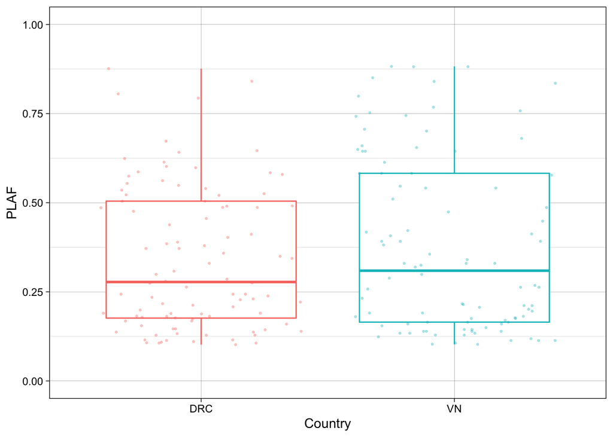

```r
plaf %>%
  ggplot() +
  geom_boxplot(aes(x = country, y = PLAF, color = country), outlier.shape = NA) +
  geom_jitter(aes(x = country, y = PLAF, color = country),
              alpha = 0.3, size = 0.5) +
  ylim(0, 1) +
  theme_linedraw() +
  theme(legend.position = "none") +
  labs(y = "PLAF", x = "Country")
```

**Q9:** What is the minimum, mean, and maximum PLAF value for each population?

Click For Answer

**A9:** *The minimum and maximum values are 0.1 and 0.9 for each population. The means are 0.37 for VN, and 0.34 for the DRC.*

**Q10:** Are these two SNP sets the same? Should they be the same?

Click For Answer

**A10:** *No, the SNP sets for the two populations are different. This is because your instructors sampled the SNPs randomly for each population. Ideally, when compare two distinct populations the SNPs you use should be identical.*

### 2.4.2 Exploring the number of heterozygous sites per sample

As we learned in our toy example, the number of heterozygous sites in a given sample is related to that samples COI. Compute the number of heterozygous sites for each sample.

```r
n_hets <- combined_long %>%
  dplyr::group_by(Indiv, country) %>%
  dplyr::summarise(
    # multiple by 2 to assume diploid genome
    n_sites = length(gt),
    n_hets = sum(gt == 0.5, na.rm=T)
  )
```

Visualise the number of heterozygous sites for each sample.

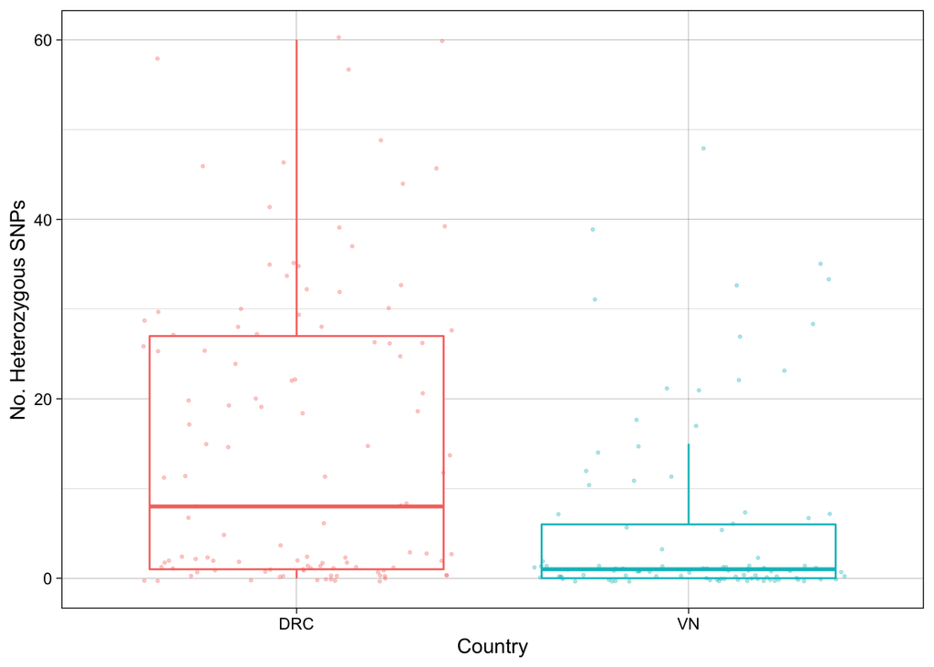

```r
n_hets %>%
  ggplot() +
  geom_boxplot(aes(x = country, y = n_hets, color = country), outlier.shape = NA) +
  geom_jitter(aes(x = country, y = n_hets, color = country),
              alpha = 0.3,size = 0.5) +
  theme_linedraw() +
  theme(legend.position = "none") +
  labs(y = "No. Heterozygous SNPs", x = "Country")
```

# 3 Estimating COI with THEREALMcCOIL (RMCL)

In this section we will create estimates of COI using THEREALMcCOIL (RMCL). For further details on the method, please take time to review the [Github](https://github.com/EPPIcenter/THEREALMcCOIL/) and [manuscript](https://www.ncbi.nlm.nih.gov/pmc/articles/PMC5300274/). We will be focusing on the [*categorical* method](https://github.com/EPPIcenter/THEREALMcCOIL/tree/master/categorical_method).

## 3.1 Reformatting data for RMCL

Before running RMCL, we need to do some additional reformating our SNP genotype data. The format required by RMCL is described [here] (https://github.com/EPPIcenter/THEREALMcCOIL/tree/master/categorical_method). First we will convert our long data frame `combined_long` into a wide data frame:

```r
# wide format
combined_RMCL <- combined_long %>%
  dplyr::mutate(loci = paste(CHROM, POS, sep = "|")) %>%
  dplyr::select(c("loci", "Indiv", "gt")) %>%
  # liftover missing for RMCL
  dplyr::mutate(gt = ifelse(is.na(gt), -1, gt)) %>%
  tidyr::pivot_wider(names_from = "Indiv",
                     values_from = "gt")
```

Now separate your newly formed wide format into a wide format for DRC and VN, respectively.

```r
DRCsmpls <- colnames(DRCongo@gt)[2:ncol(DRCongo@gt)]
VNsmpls <- colnames(Vietnam@gt)[2:ncol(Vietnam@gt)]
DRC_RMCL <- combined_RMCL[,c("loci", DRCsmpls)]
VN_RMCL <- combined_RMCL[,c("loci", VNsmpls)]
```

Now lift over values and into a matrix to conform with the RMCL expected input.

**Q11**: Complete the code chunk below (filling in *** with your own code) to convert the data into a RMCL format for VN using the DRC as an example.

```
# DRC
DRC_RMCLmat <- as.matrix(DRC_RMCL[2:ncol(as.matrix(DRC_RMCL))])
rownames(DRC_RMCLmat) <- DRC_RMCL[["loci"]]
DRC_RMCLmat <- t(DRC_RMCLmat)
# VN
VN_RMCLmat <- as.matrix(***)
rownames(VN_RMCLmat) <- VN_RMCL[[***]]
VN_RMCLmat <- t(***)
```

Click For Answer

**A11**:

```r
# make matrix and format for RMCL
# DRC
DRC_RMCLmat <- as.matrix(DRC_RMCL[2:ncol(as.matrix(DRC_RMCL))])
rownames(DRC_RMCLmat) <- DRC_RMCL[["loci"]]
DRC_RMCLmat <- t(DRC_RMCLmat)
# VN
VN_RMCLmat <- as.matrix(VN_RMCL[2:ncol(as.matrix(VN_RMCL))])
rownames(VN_RMCLmat) <- VN_RMCL[["loci"]]
VN_RMCLmat <- t(VN_RMCLmat)
```

## 3.2 Running RMCL

Now run the RMCL using the default settings provided in the [Github](https://github.com/EPPIcenter/THEREALMcCOIL/) for the DRC and VN. Note, you will need to create an output directory for results to send your output file to. For convenience, please copy and paste the code chunk below into your console.

```r
# Prepare output directory
output_dir <- "results"
if (!dir.exists(output_dir)) {
  dir.create(output_dir)
}

# Source code, move into correct working direcory
orig_wd <- getwd()
setwd("THEREALMcCOIL/categorical_method/")
source("McCOIL_categorical.R")

# DRC
output_path <- file.path(output_dir, "output_DRC_COI")
McCOIL_categorical(DRC_RMCLmat,
                   maxCOI=25, threshold_ind=20,
                   threshold_site=20,
                   totalrun=1000, burnin=100, M0=15,
                   e1=0.05, e2=0.05,
                   err_method=3,
                   path=getwd(),
                   output=file.path("..", "..", output_path) # Up from THEREALMcCOIL/categorical/
)
```

```
## Time = 2.00 s
```

```r
# VN
output_path <- file.path(output_dir, "output_VN_COI")
McCOIL_categorical(VN_RMCLmat,
                   maxCOI=25, threshold_ind=20,
                   threshold_site=20,
                   totalrun=1000, burnin=100, M0=15,
                   e1=0.05, e2=0.05,
                   err_method=3,
                   path=getwd(),
                   output=file.path("..", "..", output_path) # Up from THEREALMcCOIL/categorical/
)
```

```
## Time = 2.00 s
```

```r
# Return to our original working directory
setwd(orig_wd)
```

If you see a message indicating the time it took to run RMCL… then you’ve successfully estimated COI, congratulations!

## 3.3 Exploring RMCL outputs

The outputs from THEREALMcCOIL are written to files in your specificed output directory. Let’s load these files and explore our results.

**Q12**: Complete the code chunk below (filling in *** with your own code) to filter your THEREALMcCOIL results to the relevant bits for VN using the DRC as an example. Then combine your results into one large dataframe.

```
# Load summary data for DRC
DRCongo_COI <- read.table("results/output_DRC_COI_summary.txt", sep="\t", header=TRUE) %>%
  # Subset to COI results
  dplyr::filter(CorP == "C") %>%  # subset to COI information
  # select to rows we care about
  dplyr::select(-c("file", "CorP")) %>%
  dplyr::rename(Indiv = name)
DRCongo_COI$country <- "DRC"

# load summary data for VN
VN_COI <- read.table("results/output_VN_COI_summary.txt", sep="\t", header=TRUE) %>%
  dplyr::filter(***) %>%
  dplyr::select(***) %>%
  dplyr::rename(Indiv = ***)
VN_COI$country <- "VN"

combined_COI <- dplyr::bind_rows(DRCongo_COI, ***)
```

Click For Answer

**A12:**

```r
# Load summary data for DRC
DRCongo_COI <- read.table("results/output_DRC_COI_summary.txt", sep="\t", header=TRUE) %>%
  # Subset to COI results
  dplyr::filter(CorP == "C") %>%  # subset to COI information
  # select to rows we care about
  dplyr::select(-c("file", "CorP")) %>%
  dplyr::rename(Indiv = name)
DRCongo_COI$country <- "DRC"

# load summary data for VN
VN_COI <- read.table("results/output_VN_COI_summary.txt", sep="\t", header=TRUE) %>%
  # Subset to COI results
  dplyr::filter(CorP == "C") %>%
  # select to rows we care about
  dplyr::select(-c("file", "CorP")) %>%
  dplyr::rename(Indiv = name)
VN_COI$country <- "VN"

# now merge results
combined_COI <- dplyr::bind_rows(DRCongo_COI, VN_COI)
```

Let’s visualise the COI distributions for DRC and VN by making a boxplot contrasting the two distributions. **Q13**: Complete the code chunk below (filling in *** with your own code) to make a boxplot of your results.

```
combined_COI %>%
  ggplot() +
  geom_boxplot(***, outlier.shape = NA) +
  geom_jitter(***,
              alpha = 0.3, size = 0.5, height=0.1) +
  theme_linedraw() +
  theme(legend.position = "none") +
  labs(y = "COI", x = "Country")
```

Click For Answer

**A13:**

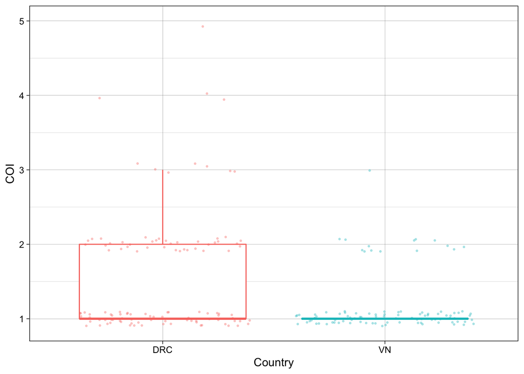

```r
combined_COI %>%
  ggplot() +
  geom_boxplot(aes(x = country, y = mean, color = country), outlier.shape = NA) +
  geom_jitter(aes(x = country, y = mean, color = country),
              alpha = 0.3, size = 0.5, height=0.1) +
  theme_linedraw() +
  theme(legend.position = "none") +
  labs(y = "COI", x = "Country")
```

**Q14:** Are there any differences in COI between the two countries? If so, can you explain them?

Click For Answer

**A14:** *Yes, the COI estimates are generally higher in DRC than in VN. This could be explained by differences in transmission intensity between the two countries.*

**Q15:** Using `tidyverse` commands: `group_by` and `summarise`, compute the fraction of mixed infectios for each country.

Click For Answer

**A15:**

```r
combined_COI %>%
  group_by(country) %>%
  summarise(frac_mixed = sum(mean > 1)/n())
```

```
## # A tibble: 2 x 2
##   country frac_mixed
##   <chr>        <dbl>
## 1 DRC          0.425
## 2 VN           0.155
```

# 4 Compute Fws

Our next task will be to compute Fws. From the lecture we learned that the Fws statistic describes how much diversity is lost in an individual sample, relative to its population of origin. For each SNP, it is computed with the following formula:

$$F_{ws} = 1- \frac{H_{wsaf}}{H_{plaf}},$$
where the $H$ terms refer to heterozygosities:

$$H = 2p(1-p),$$

where $p$ is an alterate allele frequency, either computed within a sample ($H_{wsaf}$) or across a population ($H_{plaf}$).

By averaging Fws estimates for all SNPs in a sample, you can obtain a per sample estimate.

## 4.1 Compute WSAF

First we will compute within-sample alternative allele frequencies (WSAF), which will allow us to compute $H_{wsaf}$. The WSAF for a SNP is defined as:

$$WSAF = \frac{\mbox{Number of reads carrying alternative allele}}{\mbox{Total number of reads overlapping SNP}}$$
We will add WSAF estimates as a column to the `combined_long` data frame produced above.

**Q16:** Complete the code chunk below to calculate the WSAF per sample.

```
combined_long <- combined_long %>%
  dplyr::mutate(
    rad = purrr::map_dbl(gt_AD, function(x){vcfR::masplit(
      as.matrix(x), record = 1, sort = FALSE, decreasing = FALSE)}),
    aad = purrr::map_dbl(gt_AD, function(x){vcfR::masplit(
      as.matrix(x), record = 2, sort = FALSE, decreasing = FALSE)}),
    wsaf = ***,
    wsaf = ifelse(is.nan(wsaf), NA, wsaf) # occurs when 0/0
  ) %>%
  dplyr::select(c("CHROM", "POS", "Indiv", "gt", "country", "wsaf"))
```

Click For Answer

**A16:**

```r
# extract GT information and get WSAF for every sample at each loci
combined_long <- combined_long %>%
  # lets make some new variables
  dplyr::mutate(
    rad = purrr::map_dbl(gt_AD, function(x){vcfR::masplit(
      as.matrix(x), record = 1, sort = FALSE, decreasing = FALSE)}),
    # get alternate allele depth
    aad = purrr::map_dbl(gt_AD, function(x){vcfR::masplit(
      as.matrix(x), record = 2, sort = FALSE, decreasing = FALSE)}),
    # calculate within-sample reference allele freq
    wsaf = aad/(rad + aad),
    wsaf = ifelse(is.nan(wsaf), NA, wsaf) # occurs when 0/0
  ) %>%
  # now let's select the variables that we want
  dplyr::select(c("CHROM", "POS", "Indiv", "gt", "country", "wsaf"))
```

## 4.2 Compute heterozygosity

Now we will compute heterozygosities using our PLAF and WSAF values. First, we will implement the heterozygosity function above as an R function:

```r
calc_biallelic_heterozygosity <- function(p_alt) {
  return (2 * p_alt * (1 - p_alt))
}
```

Now, let’s use our function to compute the heterozygosity from our PLAF:

```r
# calculate het for pop
plaf <- plaf %>%
  dplyr::mutate(
    het_plaf = purrr::map_dbl(PLAF, calc_biallelic_heterozygosity)
  )
```

Here, you will see we have *one* heterozygosity value for *each* of our sites.

Now, proceed to compute the heterozygosity using WSAF values.

```r
combined_long <- combined_long %>%
  # lets make some new variables
  dplyr::mutate(
    het_wsaf = calc_biallelic_heterozygosity(wsaf)
  )
```

In this case, we have one value for each sample by each site.

Now we will use our heterozygosity values to compute Fws!

**Q17**:

```
combined_long_fws <- dplyr::full_join(combined_long, plaf, by = c("CHROM", "POS", "country")) %>%
  dplyr::mutate(Fwsloci = het_wsaf / het_plaf) %>%
  dplyr::group_by(country, Indiv) %>%
  dplyr::summarise(
    fws = mean( 1 - ***, na.rm = T)
  )
```

Click For Answer

**A17:**

```r
# now calculate fws
combined_long_fws <- dplyr::full_join(combined_long, plaf, by = c("CHROM", "POS", "country")) %>%
  dplyr::mutate(Fwsloci = het_wsaf / het_plaf) %>%
  dplyr::group_by(country, Indiv) %>%
  dplyr::summarise(
    fws = mean( 1 - het_wsaf / het_plaf, na.rm = T)
  )
```

Finally, visualise your Fws values:

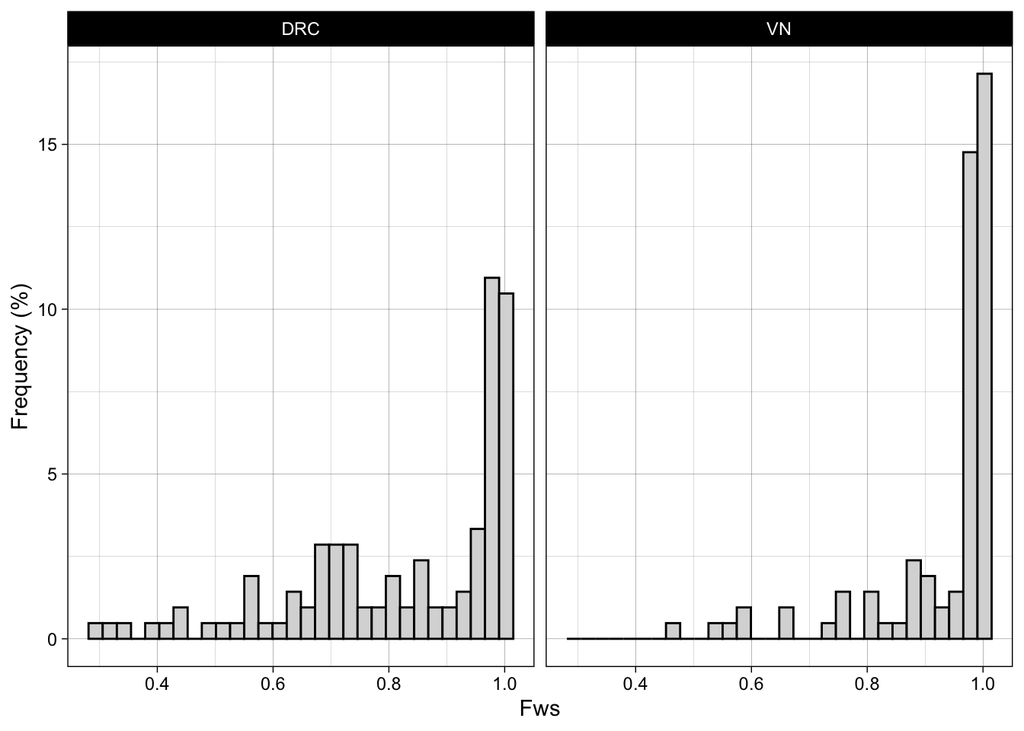

```r
combined_long_fws %>%
ggplot() +
  geom_histogram(aes(x=fws, y = (..count../sum(..count..))*100),
                 color = "#000000", fill = "#d9d9d9") +
  facet_wrap(~country) +
  xlab("Fws") + ylab("Frequency (%)") +
  theme_linedraw()
```

**Q18:** Do the Fws conform to expectation? Explain.

Click For Answer

**A18:** *Here, we see that DRC has *lower* Fws than VN. Again, this would be expected if transmission intensity were higher in the DRC.*